# Data: Multi-environment field trials provide insights into wheat yield stability and breeding progress

Published

September 12, 2025

## 1 Hyperlinks

[figure not shown]

## 2 Previous publications

[figure not shown]

[figure not shown]

[figure not shown]

[figure not shown]

[figure not shown]

additional depositories

- [adjusted mean fungal disease zenodo](https://zenodo.org/records/3697514)
- [SNIP data1, Voss-Fels 2019](https://static-content.springer.com/esm/art%3A10.1038%2Fs41477-019-0445-5/MediaObjects/41477_2019_445_MOESM4_ESM.xlsx), [SNIP data2, Lichthardt 2020](https://www.frontiersin.org/journals/plant-science/articles/10.3389/fpls.2019.01771/full#supplementary-material)
- [Adjusted mean zenodo](https://zenodo.org/records/1316947)
- [climate, soil water and coefficient zenodo](https://zenodo.org/records/8248543)

## 3 Hightlights

**561722 traits from 228 genotypes across 6 years, 6 locations and 9 managements**

**BRIWECs MET dataset**

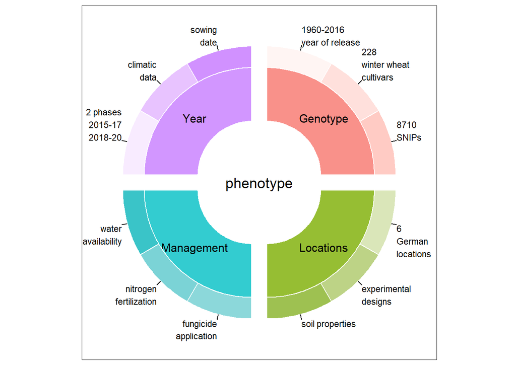

Figure 1

**228 Genotypes**

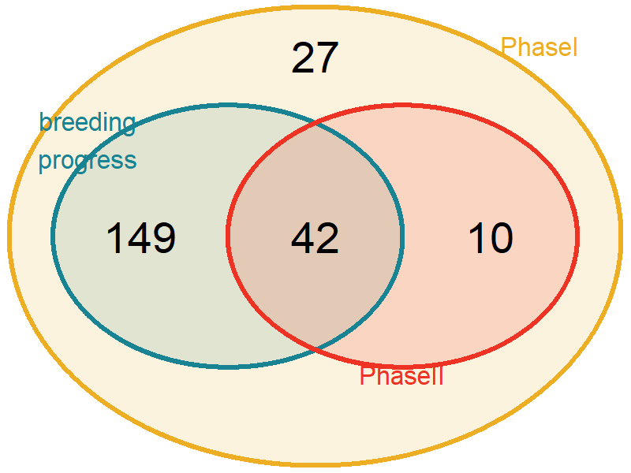

Figure 2: 228 genotypes

**6 Locations**

| Full name | Abbreviation |
| --- | --- |
| Gross Gerau | GGE |
| Hannover | HAN |
| Klein Altendorf | KAL |
| Kiel | KIE |
| Quedlinburg | QLB |
| Rauischholzhausen | RHH |

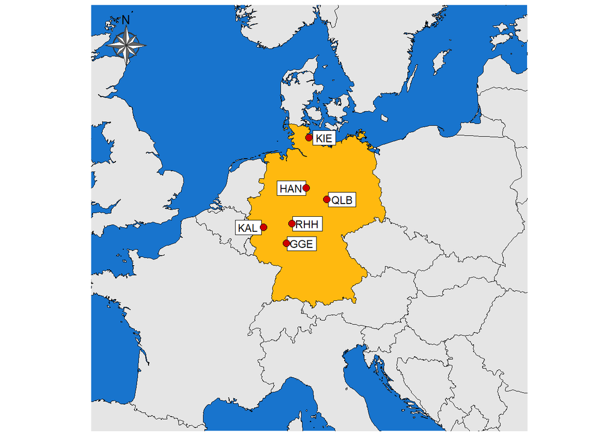

Figure 3: map-location

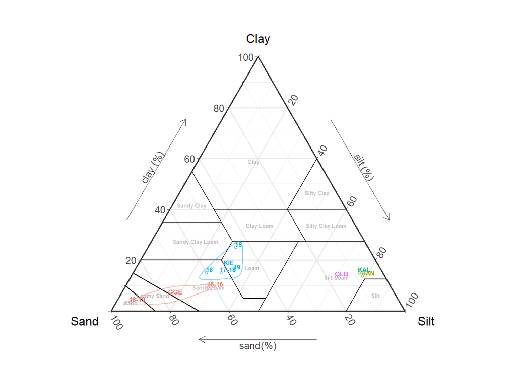

Figure 4: soil-location

**9 Managements**

Management comprises of three treatments: nitrogen fertilizer, fungicide application and water availability.

- Nitrogen fertilizer treatment includes two application levels: high (HN: 220 kg N ha<sup>-1</sup>) and low (LN: 110 kg N ha<sup>-1</sup>), both include soil mineral nitrogen (0–90 cm) measured in early spring.
- Fungicide treatment contains two application levels: with (WF) or without (NF) fungicide application.
- Water availability treatment has three levels: rain-fed (RF), irrigated (IR) and rainout-shelter treated (RO).

In total, there are 9 managements, while it is incomplete and depends on the location and years (Figure 5, Table 1).

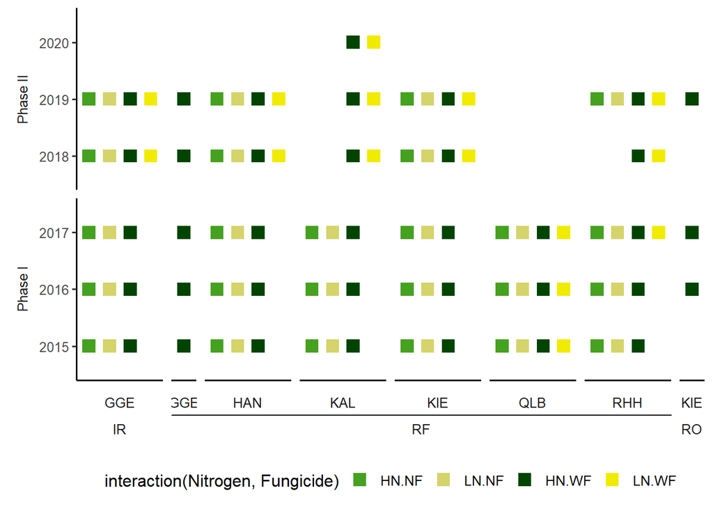

Figure 5: -management

Table 1: managements

| Nitrogen | Fungicide | Water_availability |
| --- | --- | --- |
| HN | WF | RO |
| LN | NF | IR |
| HN | NF | IR |
| HN | WF | IR |
| HN | WF | RF |
| LN | WF | IR |
| HN | NF | RF |
| LN | NF | RF |
| LN | WF | RF |

**24 agronomic and physiological traits**

Total: 561,7K observations (removed outliers)

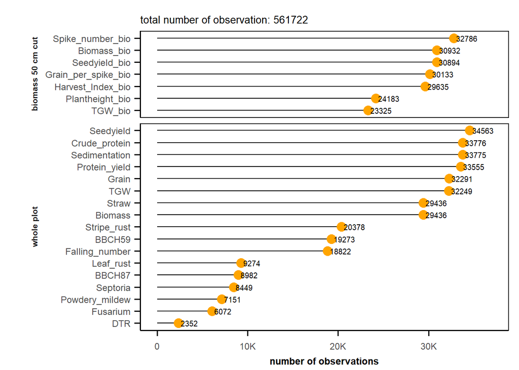

Figure 6: overview-datapoint

## 4 Experimental designs

**2015**

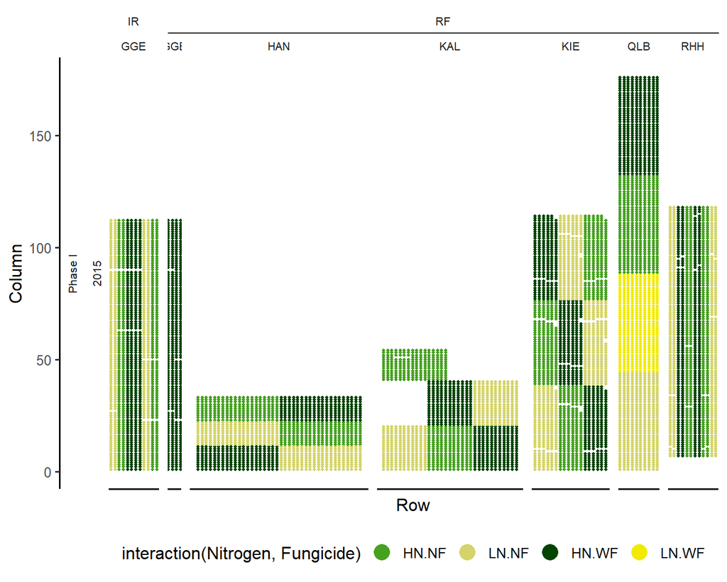

Figure 7: 2015-exp

**2016**

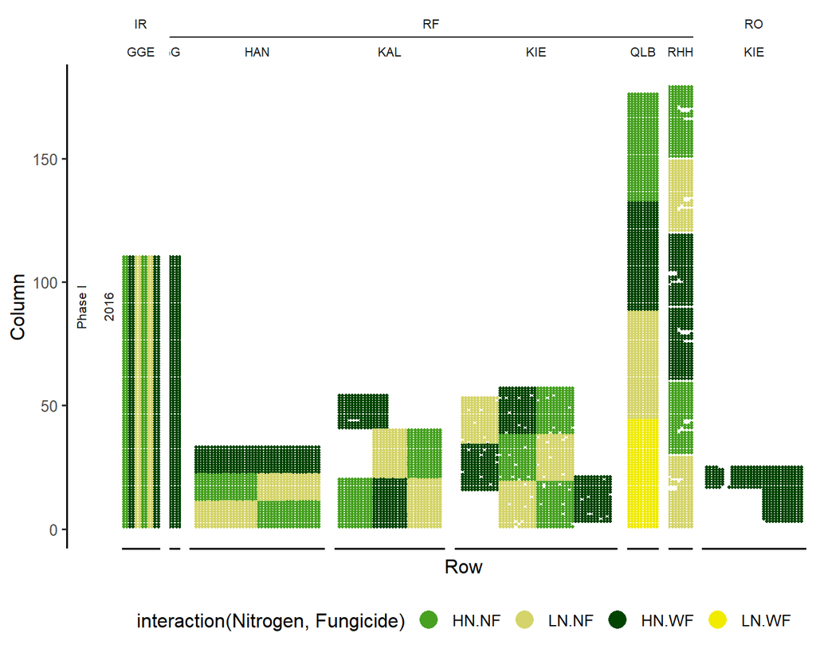

Figure 8: 2016-exp

**2017**

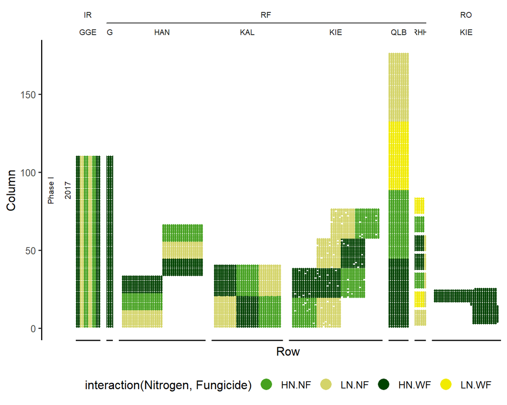

Figure 9: 2017-exp

**2018**

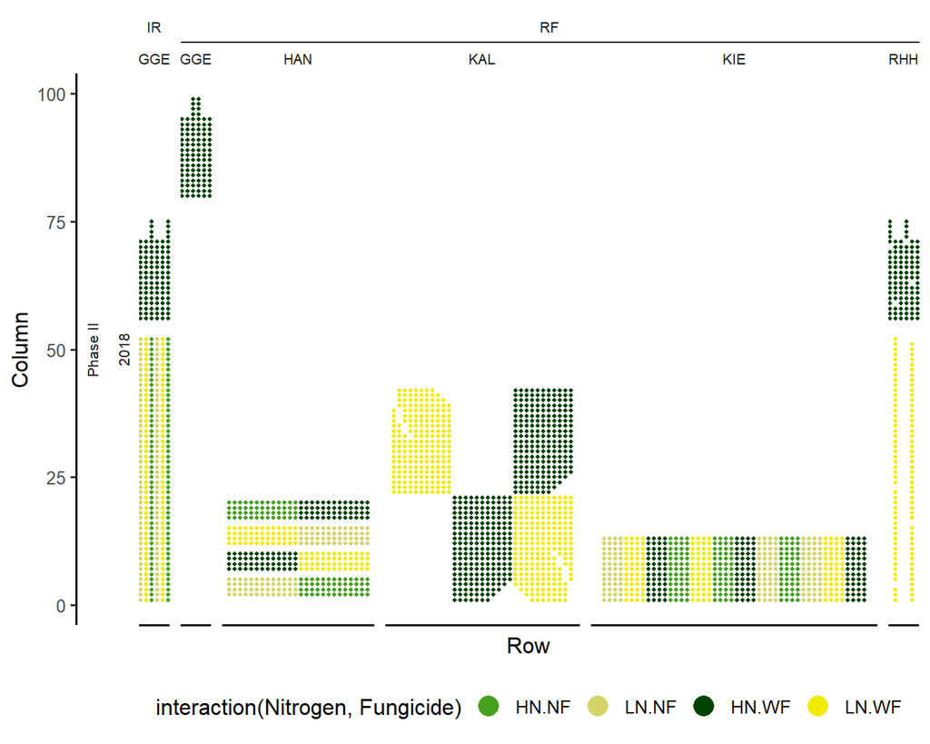

Figure 10: 2018-exp

**2019**

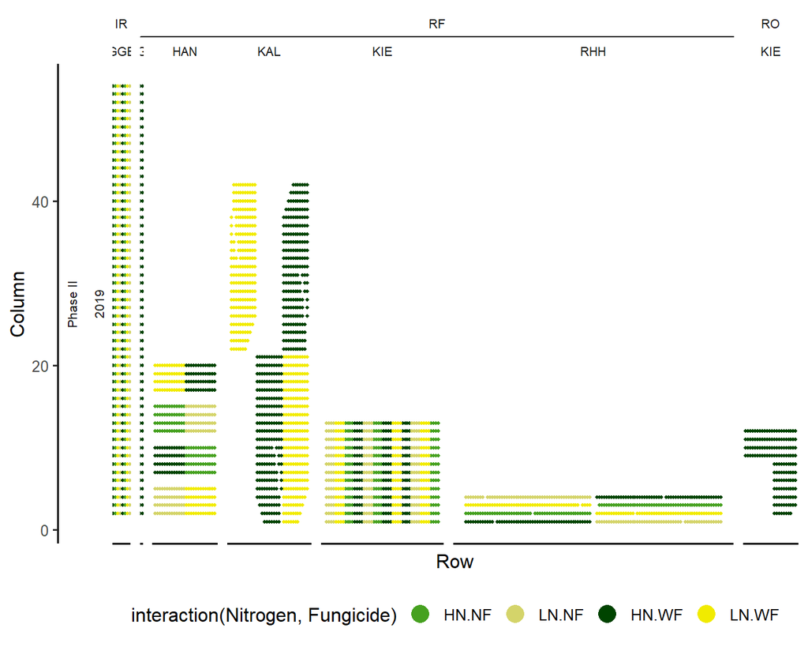

Figure 11: 2019-exp

**2020**

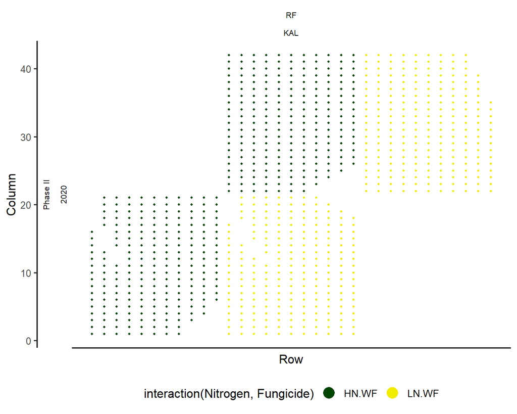

Figure 12: 2020-exp

In KAL 2018–2020 an additional treatment without nitrogen treatment was added to the experimental design. This management is excluded from the data set.

## 5 24 Traits

Table 2: Trait names, sources, ranges and units

| trait full name | trait source | column name | trait range | unit |
| --- | --- | --- | --- | --- |
| above-ground dry biomass | 50 cm cut | Biomass_bio | 0~3495 | g/m^2 |
| grains per spike | 50 cm cut | Grain_per_spike_bio | 3.6~146.7 | Nbr. |
| harvest index | 50 cm cut | Harvest_Index_bio | 0.1~0.8 |  |
| plant height | 50 cm cut | Plantheight_bio | 40~145 | cm |
| grain yield | 50 cm cut | Seedyield_bio | 28.3~1815 | g/m^2 @100% dry mass |
| spike number | 50 cm cut | Spike_number_bio | 48~1390 | Nbr./m^2 |
| thousand grain weight | 50 cm cut | TGW_bio | 4.7~77.8 | g |
| day when 75% of the ears are visible | whole plot | BBCH59 | 123~181 | days of year |
| day when 75% hard dough | whole plot | BBCH87 | 175~213 | days of year |
| above-ground dry biomass | whole plot | Biomass | 14.2~732.8 | dt/ha |
| crude protein percentage per grain dry mass | whole plot | Crude_protein | 6.2~21.3 | % |
| leaf tan spot caused by Drechslera tritici-repentis | whole plot | DTR | 0~100 | % leaf area |
| falling number | whole plot | Falling_number | 60~700 | s |
| fusarium head blight | whole plot | Fusarium | 0~27 | % spike |
| number of grains per unit area | whole plot | Grain | 19.2~5851.5 | Nbr.*10^5/ha |
| leaf rust caused by Puccinia triticina eriks. | whole plot | Leaf_rust | 0~90 | % leaf area |
| leaf powdery mildew | whole plot | Powdery_mildew | 0~100 | % leaf area |
| grain protein yield | whole plot | Protein_yield | 0.005~22.2 | dt/ha |
| sedimentation | whole plot | Sedimentation | 2.1~95.4 | ml |
| grain yield | whole plot | Seedyield | 0.05~141.6 | dt/ha @100% dry mass |
| leaf spot caused by Septoria tritici | whole plot | Septoria | 0~80 | % leaf area |
| above ground biomass substracted by grain yield | whole plot | Straw | 8.9~625.4 | dt/ha |
| stripe rust caused by Puccinia striiformis | whole plot | Stripe_rust | 0~100 | % leaf area |
| thousand grain weight | whole plot | TGW | 2.6~69.5 | g |

## 6 Ranges of traits

### 6.1 Agronomic traits

#### 6.1.1 `Seedyield`

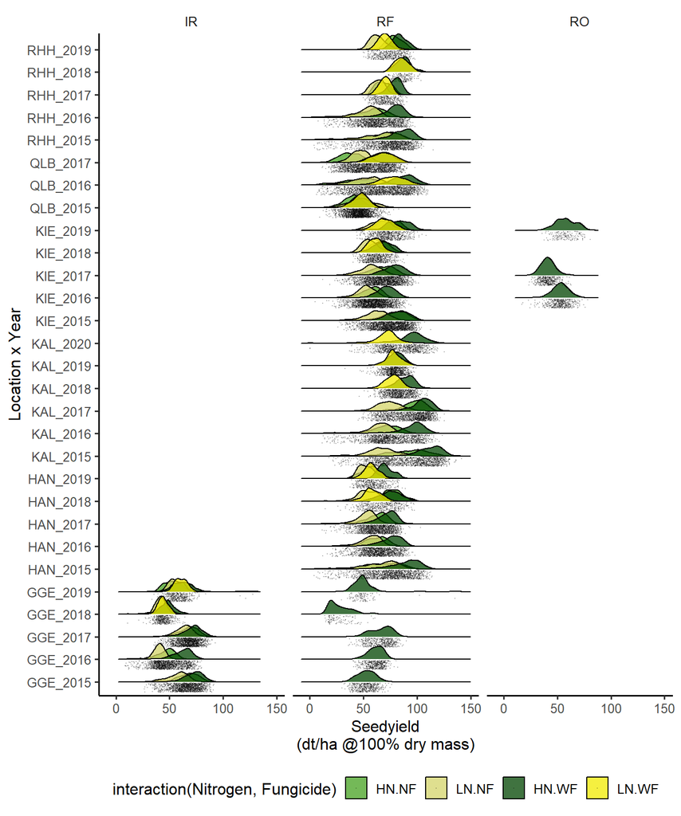

Figure 13: Seedyield-distribution

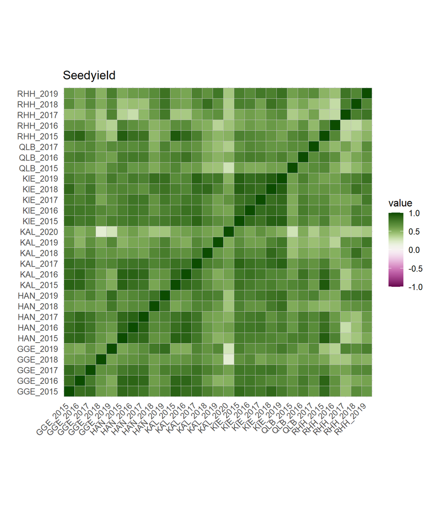

Figure 14: Seedyield-correlation

#### 6.1.2 `Seedyield_bio`

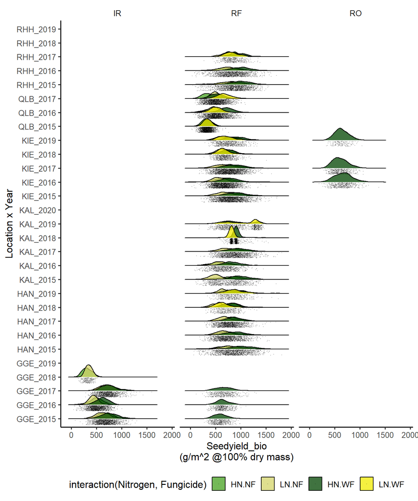

Figure 15: Seedyield_bio-distribution

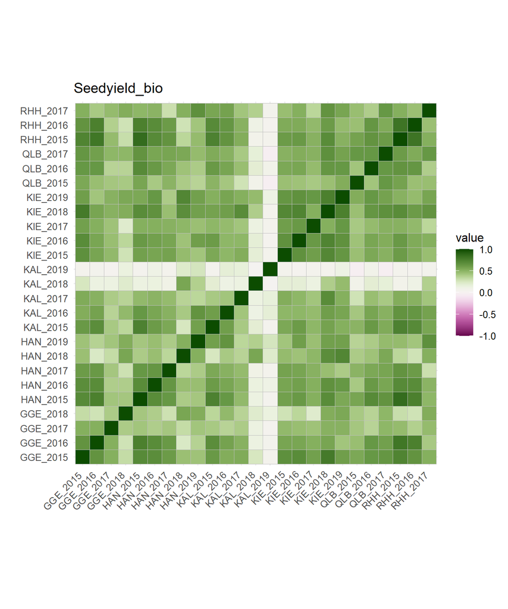

Figure 16: Seedyield_bio-correlation

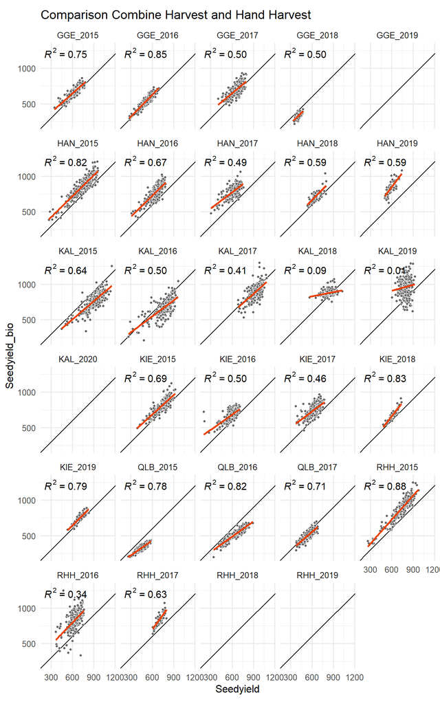

Figure 17: correlations between whole plot and 50 cm cut

#### 6.1.3 `Biomass_bio`

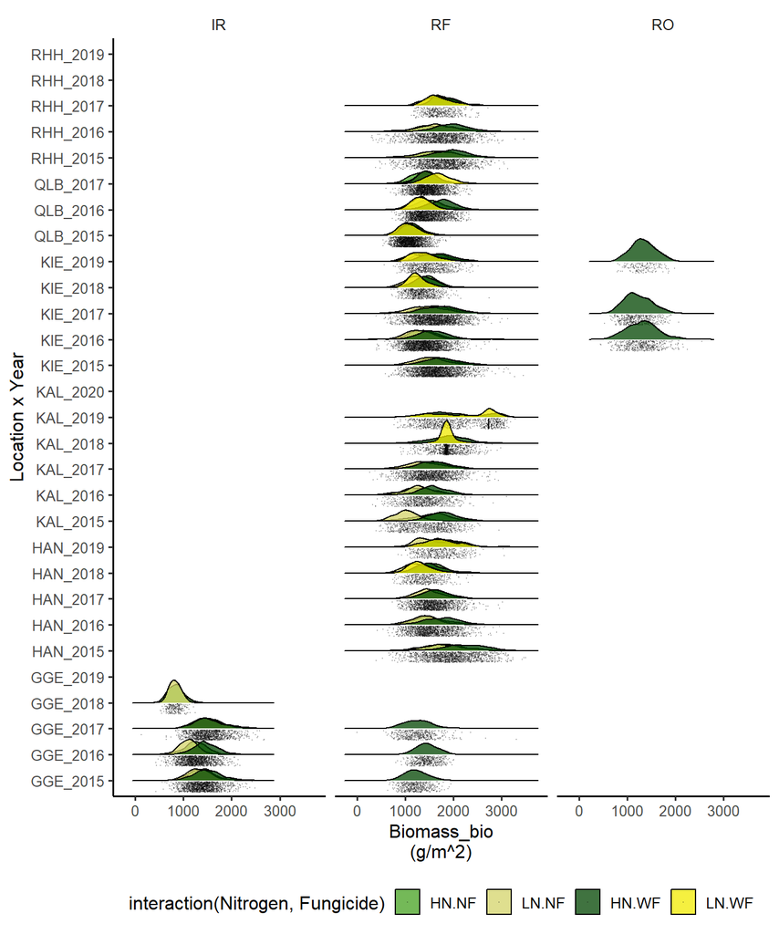

Figure 18: Biomass_bio-distribution

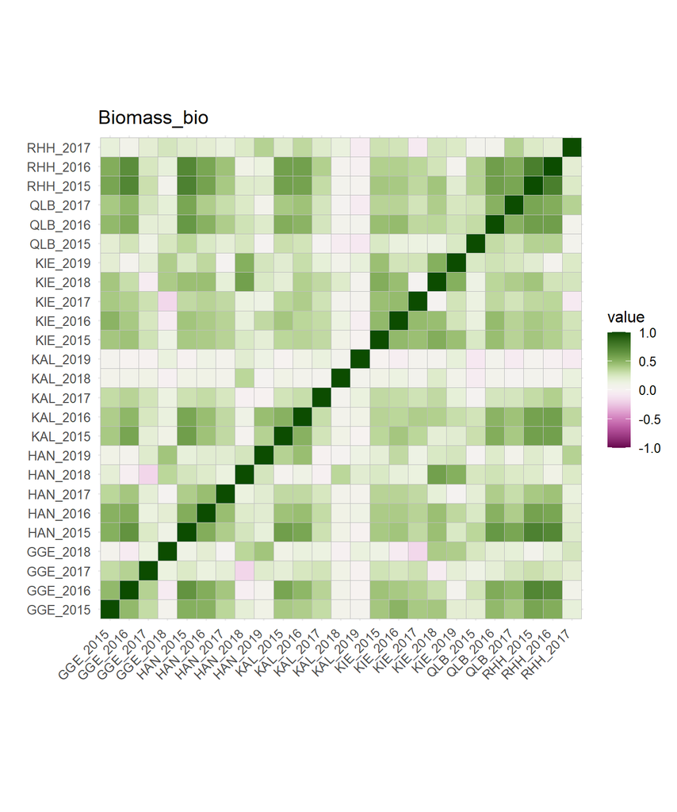

Figure 19: Biomass_bio-correlation

#### 6.1.4 `Harvest_Index_bio`

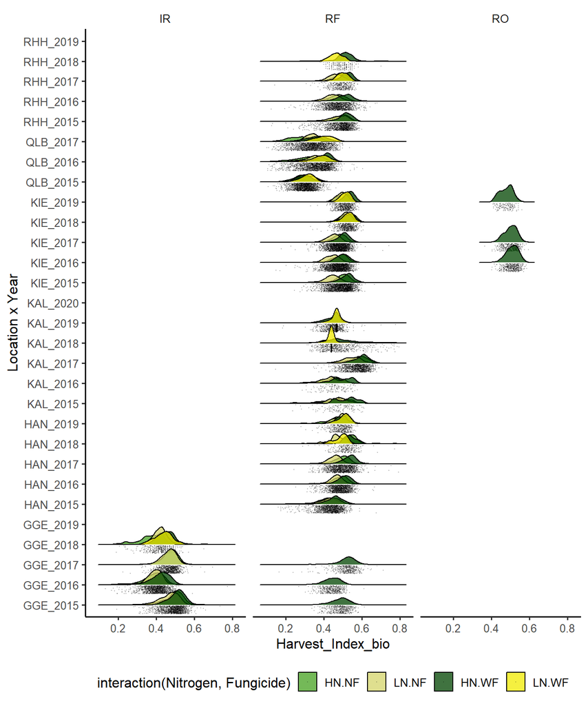

Figure 20: Harvest_Index_bio-distribution

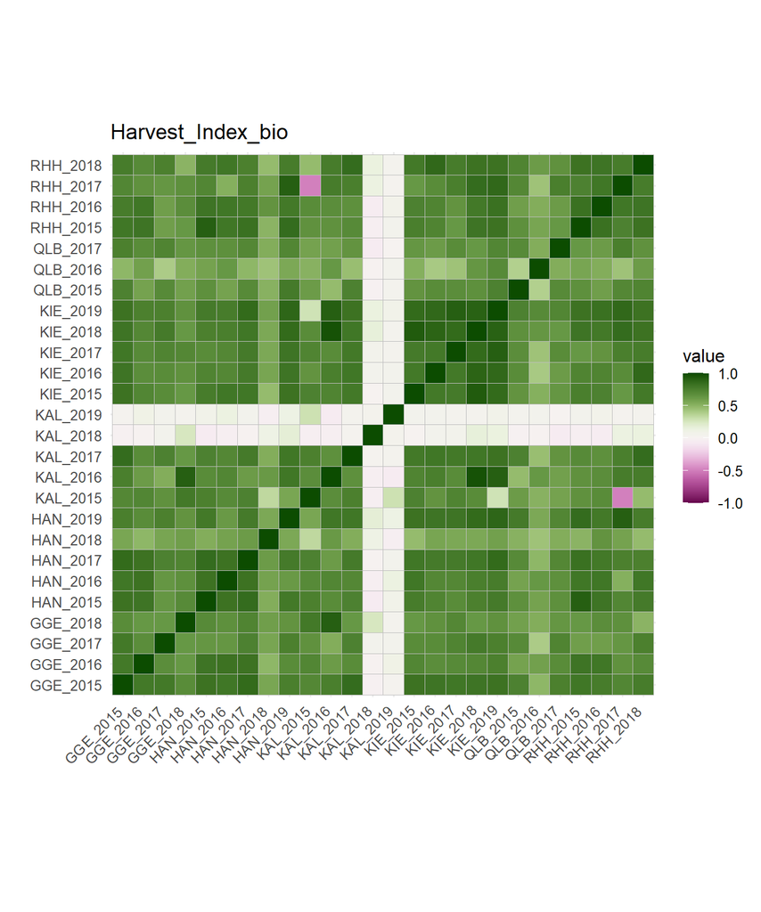

Figure 21: Harvest_Index_bio-correlation

#### 6.1.5 `TGW`

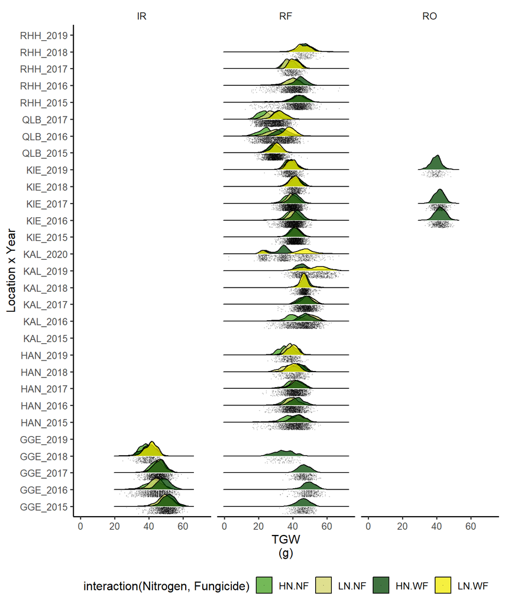

Figure 22: TGW-distribution

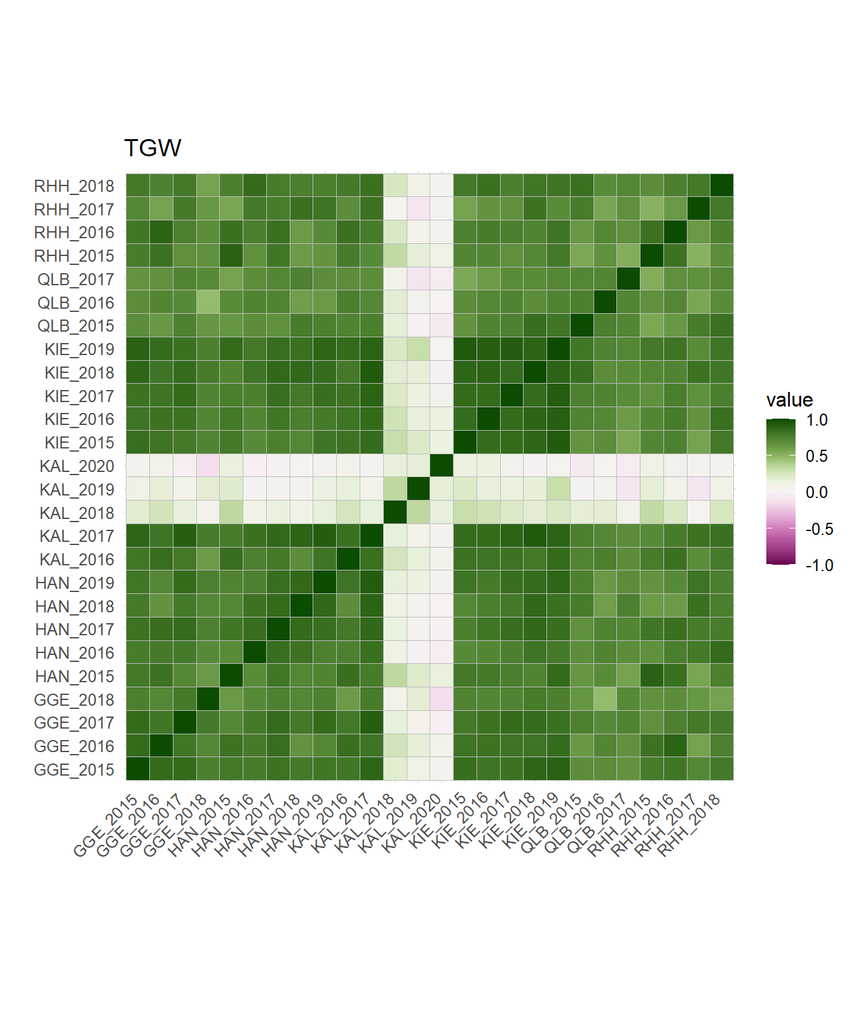

Figure 23: TGW-correlation

#### 6.1.6 `TGW_bio`

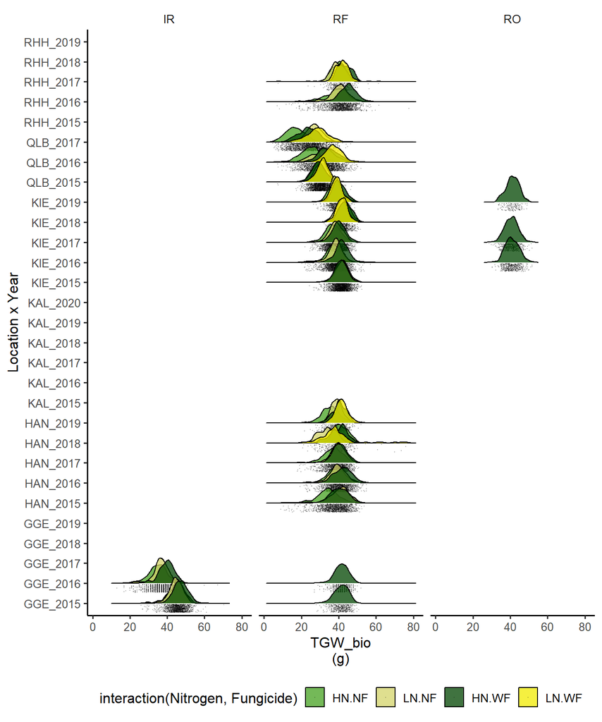

Figure 24: TGW_bio-distribution

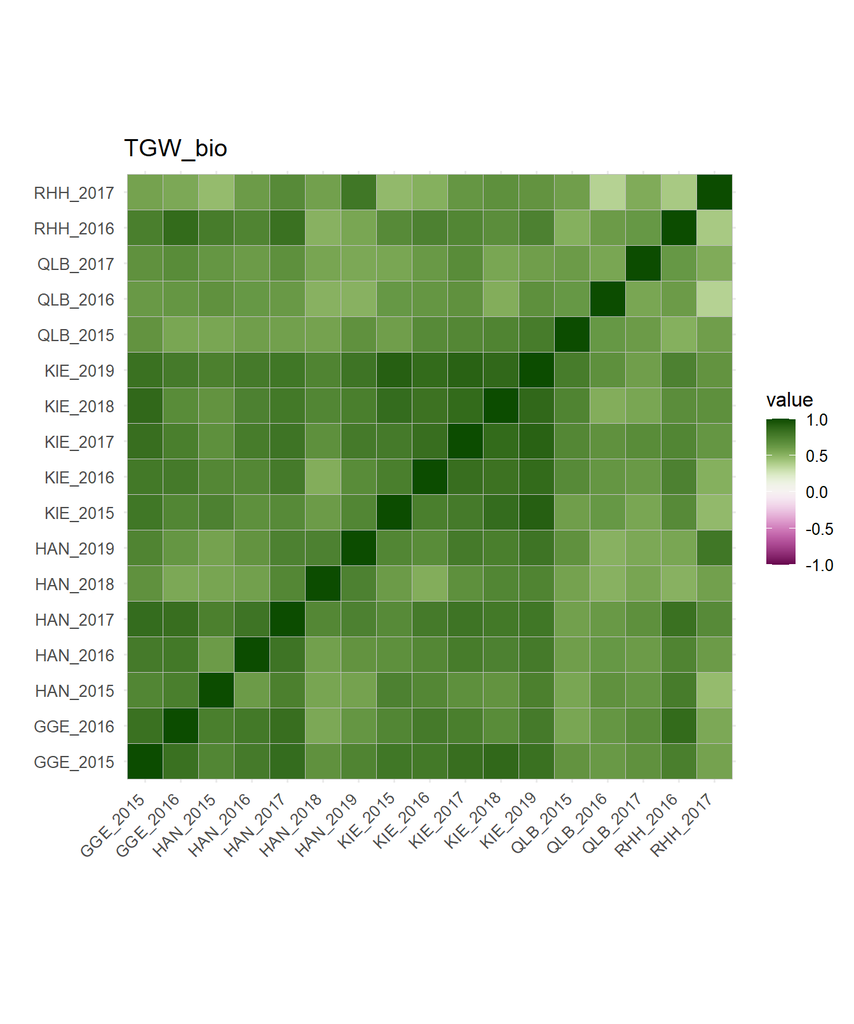

Figure 25: TGW_bio-correlation

#### 6.1.7 `Spike_number_bio`

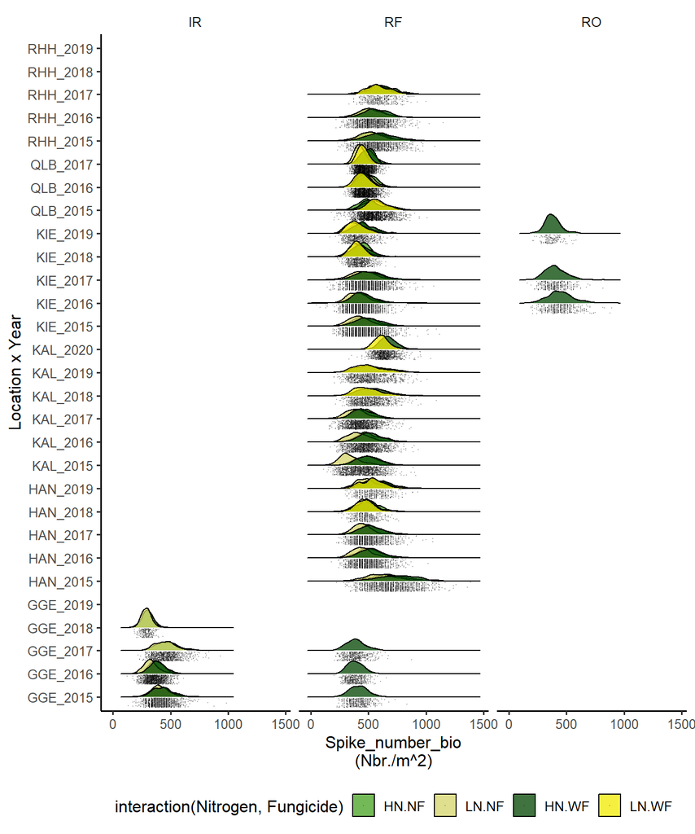

Figure 26: Spike_number_bio-distribution

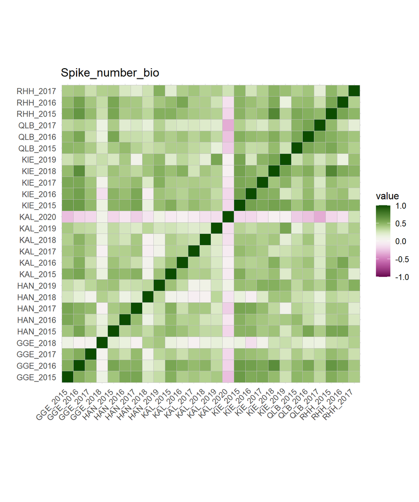

Figure 27: Spike_number_bio-correlation